# Web scraping with R

## Introduction

Data scientists are working with data all the time. The most often the data are provided by task owner/project manager. Those data are crucial. However, sometimes the data doesn’t exist (are not generated), or would be great to enrich the existing data with some additional features – e.g. weather, social network comments, forums etc. Internet is one of the best/biggest data sources for many areas - social media research, various online marketing campaigns or climate data.

In this notebook we will show how to get/scrape data from the Internet. We will demonstrate that it is relatively easy to get data also from complex web-pages with JavaScript, sessions and other modern web-programming elements.

## Web scraping

The process of getting data from a web is called [Web scraping](https://en.wikipedia.org/wiki/Web_scraping). Scraping a web page, involves fetching it and extracting data from it. There are many ways and tools how to do it. In this notebook we will work with R since R is routinely used by many data scientist.

We will show how to scrape data technically, however we need to be aware of law aspect as well. Some companies do not want to process their pages by robots. The law is not complete and it varies country by country and it is still evolving.

### Simple approach – mainly static context

Let’s do the web scraping with rvest package. First, we need to find/localize what data we are interested in. We need to know [*XPath*](https://www.w3schools.com/xml/xpath_intro.asp) or some other form of the location within the web page. For this, we can use [Firebug](http://getfirebug.com/) plugin (there are many similar tools).

Let’s say we want to get information about a score in film from [IMDB](http://www.imdb.com). We pick one particular movie, e.g. [The Lego Movie](http://www.imdb.com/title/tt1490017/), open it in Firefox and activate the Firebug plugin.

[figure not shown]

Click on the element inspector (number 1 in the picture above), find the element with the score and click on it (number 2), Firebug will emphasize the element in the page source code (number 3). We can get/copy the exact XPath/CSS/html by clicking the right button on the element. In our case it is:

- XPath: `/html/body/div[1]/div/div[4]/div[5]/div[1]/div/div/div[2]/div[2]/div/div[1]/div[1]/div[1]/strong/span`
- HTML: `<span itemprop="ratingValue">7.8</span>`

Open R Studio and start the scraping! Load libraries

```r
library(tidyverse)
```

```r
library(rvest)
```

Try to get the score

```r
lego_url <- "http://www.imdb.com/title/tt1490017/"
rating <- read_html(lego_url) %>%
  #search for elements <strong> <span>
  html_nodes("strong span") %>%
  #take a text string from span element
  html_text() %>%
  #convert to number
  as.numeric()
rating
```

```
[1] 7.8
```

With some 5 lines of R code we got the score for *The Lego Movie*. Now it should be easy to run this code against any set of movies on [IMDB](http://www.imdb.com)

This is a good approach for getting mainly static data (e.g. Wikipedia pages), however it is not possible to use for getting dynamic context (like social media that use logins and complex JavaScript).

### Scraping complex dynamic pages

A simple use case for the start – *let’s find a mean price for properties in Bronx on zillow.com*. First, we need to found out a number of properties, in the upper right corner

[figure not shown]

With Firebug, we find out - we need XPath: `//div/h2` (why this string, or what other strings might lead to the same result - is a homework for you :))

```r
properties <- read_html("https://www.zillow.com/homes/for_sale/Castle-Hill-Bronx-New-York-NY/pmf,pf_pt/270812_rid/globalrelevanceex_sort/40.828359,-73.826516,40.809652,-73.87265_rect/14_zm/") %>%
  html_nodes(xpath = '//div/h2')
```

That should be it, however if we take a look on results - it is empty

```r
length(properties)
```

```
[1] 0
```

In our web-browser there is 86 results instead …

The answer is simple but definitely not obvious. `rvest` uses `curl` for browsing/downloading web pages. `curl` is a great command line tool but definitely not good fit for JavaScript. If we check what exactly *curl* got:

```bash
curl "https://www.zillow.com/homes/for_sale/Castle-Hill-Bronx-New-York-NY/pmf,pf_pt/270812_rid/globalrelevanceex_sort/40.828359,-73.826516,40.809652,-73.87265_rect/14_zm/" > zillow_curl.html
```

```
  % Total    % Received % Xferd  Average Speed   Time    Time     Time  Current
                                 Dload  Upload   Total   Spent    Left  Speed

  0     0    0     0    0     0      0      0 --:--:-- --:--:-- --:--:--     0
100   537  100   537    0     0   1350      0 --:--:-- --:--:-- --:--:--  1352
```

Open `zillow_curl.html` in a browser – it is slightly different!

[figure not shown]

Therefore we need something that emulates a proper browser… There are great tools: [PhantomJs](http://phantomjs.org/) – PhantomJS is a headless WebKit scriptable with a JavaScript API. Selenium – enables web browser automation. It can work via IDE:

[figure not shown]

or a driver.

These SW are great but we would need to speak 2 extra languages: Java and JavaScript. Fortunately, there is R wrapper RSelenium. A good introduction to the package can be found in the package [vignettes](https://cran.r-project.org/web/packages/RSelenium/vignettes/), or [webinars](https://cran.r-project.org/web/packages/RSelenium/vignettes/OCRUG-webinar.html)

Now, let’s go back to our task

```r
library(tidyverse)
library(RSelenium)
```

Initialize our session (browser).

```r
rD <- rsDriver(port=6539L, browser = "firefox")
```

[output not shown]

[output not shown]

```r
remDr <- rD$client
```

and open the page

```r
remDr$navigate("https://www.zillow.com/homes/for_sale/Castle-Hill-Bronx-New-York-NY/pmf,pf_pt/270812_rid/globalrelevanceex_sort/40.828359,-73.826516,40.809652,-73.87265_rect/14_zm/")
```

we can play with it in many ways (get exact window/item position, screenshot, etc.) For example, get a screenshot

```r
remDr$screenshot(display = TRUE)
```

[figure not shown]

We can see that the page is correct - it contains the info we need (number of properties). Let’s find the number via FireBug. Once we have the path, we can validate it via *RSelenium* (show the element with yellow background for 5 seconds)

```r
found <- remDr$findElement(using = "xpath",value='//div/h2')
found$highlightElement(wait = 5)
```

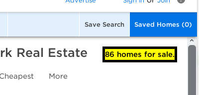

Notice the yellow background

Great! It is working. Now get the number

```r
library(stringr)
elem <- remDr$findElement(using="xpath",value='//div/h2')$getElementText()
results <- as.integer(str_match(elem[[1]],"(\\d+) homes")[[2]])
```

Similarly, check the number of pages. Please notice, we are using *findElement**s*** instead if *findElement*!

```r
elem <- remDr$findElements(using="xpath",value='//div/ol/li')
pages <- length(elem) - 1
```

Now, try to scrape the ads from the page.

One URL link per ad

```r
elem_link <- remDr$findElements(using ="xpath", value = "//article/div/a")
links <- sapply(elem_link,function(x){x$getElementAttribute(attrName = "href")})
links <- unlist(links)
head(links)
```

```
[1] "https://www.zillow.com/homedetails/940-Castle-Hill-Ave-Bronx-NY-10473/29794062_zpid/"
[2] "https://www.zillow.com/homedetails/2123-Quimby-Ave-Bronx-NY-10473/29793866_zpid/"
[3] "https://www.zillow.com/homedetails/2259-Cincinnatus-Ave-Bronx-NY-10473/29792497_zpid/"
[4] "https://www.zillow.com/homedetails/2252-Story-Ave-Bronx-NY-10473/29793982_zpid/"
[5] "https://www.zillow.com/homedetails/2125-Quimby-Ave-Bronx-NY-10473/29793865_zpid/"
[6] "https://www.zillow.com/homedetails/501-Olmstead-Ave-Bronx-NY-10473/29792136_zpid/"
```

Price per ad

```r
elem_price <- remDr$findElements(using ="css", value = 'span[class=zsg-photo-card-price]')
prices <- sapply(elem_price,function(x){x$getElementText()[[1]]})
head(prices)
```

```
[1] "$350K"    "$322K"    "$449,000" "$675,000" "$350,000" "$450,000"
```

Type of property, number of rooms and square feet

```r
elem_info <- remDr$findElements(using ="css", value = 'span[class="zsg-photo-card-info"')
info <- sapply(elem_info,function(x){tmp<-x$getElementText()[[1]];str_split(tmp,"·")})
types <- sapply(info,function(x){x[1]})
rooms <- sapply(info,function(x){x[2]})
sqfts <- sapply(info,function(x){str_trim(x[3])})
head(sqfts)
```

```
[1] "2,310 sqft" "1,334 sqft" "1,730 sqft" "2,400 sqft" "1,334 sqft" "2,345 sqft"
```

We have all the information about property type, number of rooms, price, link, and area for each ad on the page. Let’s put it into newly created tibble

```r
properties <- tibble(url=character(),price=character(),type=character(), room=character(), sqft=character())
properties <-properties %>%  add_row(url = links, price=prices, type=types, room=rooms, sqft=sqfts)
head(properties)
```

| url | price | type | room | sqft |
| --- | --- | --- | --- | --- |
| https://www.zillow.com/homedetails/940-Castle-Hill-Ave-Bronx-NY-10473/29794062_zpid/ | $350K | -- bds | -- ba | 2,310 sqft |
| https://www.zillow.com/homedetails/2123-Quimby-Ave-Bronx-NY-10473/29793866_zpid/ | $322K | 3 bds | -- ba | 1,334 sqft |
| https://www.zillow.com/homedetails/2259-Cincinnatus-Ave-Bronx-NY-10473/29792497_zpid/ | $449,000 | 3 bds | 2 ba | 1,730 sqft |
| https://www.zillow.com/homedetails/2252-Story-Ave-Bronx-NY-10473/29793982_zpid/ | $675,000 | 3 bds | 2 ba | 2,400 sqft |
| https://www.zillow.com/homedetails/2125-Quimby-Ave-Bronx-NY-10473/29793865_zpid/ | $350,000 | 2 bds | 1 ba | 1,334 sqft |
| https://www.zillow.com/homedetails/501-Olmstead-Ave-Bronx-NY-10473/29792136_zpid/ | $450,000 | 6 bds | 4 ba | 2,345 sqft |

This step sometimes fails with the error: `Error: Column`price`must be length 1 or 25, not 24`. Check the page and think about the price - why there are fewer price tags than ads?

As a final step we need to make a loop for processing each page. Here you can see we solved the issue with price - think about the difference in code.

```r
properties <- tibble(url=character(),price=character(),type=character(), room=character(), sqft=character())
for(page in 1:pages){
  print(paste("page:",page))

  #load page (1st page is already loaded - skip it)
  if(page!=1){
    url_page=paste0("https://www.zillow.com/homes/for_sale/Castle-Hill-Bronx-New-York-NY/pmf,pf_pt/270812_rid/globalrelevanceex_sort/40.828359,-73.826516,40.809652,-73.87265_rect/14_zm/",page,"_p")
    remDr$navigate(url_page)
  }
  print("Loaded")
  #links
  elem_link <- remDr$findElements(using ="xpath", value = "//article/div/a")
  links <- sapply(elem_link,function(x){x$getElementAttribute(attrName = "href")})
  links <- unlist(links)

  #prices
  elem_price <- remDr$findElements(using ="css", value = 'div[class=zsg-photo-card-caption]')
  prices <- sapply(elem_price,function(x){str_match(x$getElementText()[[1]],"\\$([\\d+,K]+)")[[2]]})
  #
  elem_info <- remDr$findElements(using ="css", value = 'span[class="zsg-photo-card-info"')
  info <- sapply(elem_info,function(x){tmp<-x$getElementText()[[1]];str_split(tmp,"·")})
  types <- sapply(info,function(x){x[1]})
  rooms <- sapply(info,function(x){x[2]})
  sqfts <- sapply(info,function(x){str_trim(x[3])})
  #add results to flats
  properties <-properties %>%  add_row(url = links, price=prices, type=types, room=rooms, sqft=sqfts)
  print(" .... OK")
}
```

```
[1] "page: 1"
[1] "Loaded"
[1] " .... OK"
[1] "page: 2"
[1] "Loaded"
[1] " .... OK"
[1] "page: 3"
[1] "Loaded"
[1] " .... OK"
[1] "page: 4"
[1] "Loaded"
[1] " .... OK"
```

Double check the results

```r
dim(properties)
```

```
[1] 88  5
```

And check the first few lines

```r
head(properties)
```

| url | price | type | room | sqft |
| --- | --- | --- | --- | --- |
| https://www.zillow.com/homedetails/940-Castle-Hill-Ave-Bronx-NY-10473/29794062_zpid/ | 350K | -- bds | -- ba | 2,310 sqft |
| https://www.zillow.com/homedetails/2123-Quimby-Ave-Bronx-NY-10473/29793866_zpid/ | 322K3 | 3 bds | -- ba | 1,334 sqft |
| https://www.zillow.com/homedetails/2259-Cincinnatus-Ave-Bronx-NY-10473/29792497_zpid/ | 449,0003 | 3 bds | 2 ba | 1,730 sqft |
| https://www.zillow.com/homedetails/2252-Story-Ave-Bronx-NY-10473/29793982_zpid/ | 675,0003 | 3 bds | 2 ba | 2,400 sqft |
| https://www.zillow.com/homedetails/2125-Quimby-Ave-Bronx-NY-10473/29793865_zpid/ | 350,0002 | 2 bds | 1 ba | 1,334 sqft |
| https://www.zillow.com/homedetails/501-Olmstead-Ave-Bronx-NY-10473/29792136_zpid/ | 450,0006 | 6 bds | 4 ba | 2,345 sqft |

### What next?

Standard feature engineering: - make *price* column consistent - Are *room* and *sqft* columns OK? - what other data/information we might need for our analysis

By solving these questions, we create a valid data source for our data science work. For example, lets count how much space is for sell (how many sqft):

```r
properties$sqft2 <- str_replace(properties$sqft, "\\s*sqft\\s*","") %>% str_replace(",","") %>% as.numeric()
sum(properties$sqft2, na.rm = TRUE)
```

```
[1] 201035
```